# Explore White Wine Quality

### By Ruchita Maheshwary

In this report, I analyzed the data set for around 5000 white wines.

This data set is used to model wine preferences by data mining from physicochemical properties. In the dataset, the inputs include objective tests (e.g. PH values) and the output is based on sensory data (median of at least 3 evaluations made by wine experts). Each expert graded the wine quality between 0 (very bad) and 10 (very excellent).

**Brief description about the dataset variables:**

- fixed acidity: most acids involved with wine or fixed or nonvolatile (do not evaporate readily)
- volatile acidity: the amount of acetic acid in wine, which at too high of levels can lead to an unpleasant, vinegar taste
- citric acid: found in small quantities, citric acid can add ‘freshness’ and flavor to wines
- residual sugar: the amount of sugar remaining after fermentation stops, it’s rare to find wines with less than 1 gram/liter and wines with greater than 45 grams/liter are considered sweet
- chlorides: the amount of salt in the wine
- free sulfur dioxide: the free form of SO2 exists in equilibrium between molecular SO2 (as a dissolved gas) and bisulfite ion; it prevents microbial growth and the oxidation of wine
- total sulfur dioxide: amount of free and bound forms of S02; in low concentrations, SO2 is mostly undetectable in wine, but at free SO2 concentrations over 50 ppm, SO2 becomes evident in the nose and taste of wine
- density: the density of water is close to that of water depending on the percent alcohol and sugar content
- pH: describes how acidic or basic a wine is on a scale from 0 (very acidic) to 14 (very basic); most wines are between 3-4 on the pH scale
- sulphates: a wine additive which can contribute to sulfur dioxide gas (S02) levels, wich acts as an antimicrobial and antioxidant
- alcohol: the percent alcohol content of the wine
- quality (score between 0 and 10): Output variable (based on sensory data)

# Univariate Plots Section

Below is a brief summary of the data:

```
## [1] 4898   13
```

```
## 'data.frame':    4898 obs. of  13 variables:
##  $ X                   : int  1 2 3 4 5 6 7 8 9 10 ...
##  $ fixed.acidity       : num  7 6.3 8.1 7.2 7.2 8.1 6.2 7 6.3 8.1 ...
##  $ volatile.acidity    : num  0.27 0.3 0.28 0.23 0.23 0.28 0.32 0.27 0.3 0.22 ...
##  $ citric.acid         : num  0.36 0.34 0.4 0.32 0.32 0.4 0.16 0.36 0.34 0.43 ...
##  $ residual.sugar      : num  20.7 1.6 6.9 8.5 8.5 6.9 7 20.7 1.6 1.5 ...
##  $ chlorides           : num  0.045 0.049 0.05 0.058 0.058 0.05 0.045 0.045 0.049 0.044 ...
##  $ free.sulfur.dioxide : num  45 14 30 47 47 30 30 45 14 28 ...
##  $ total.sulfur.dioxide: num  170 132 97 186 186 97 136 170 132 129 ...
##  $ density             : num  1.001 0.994 0.995 0.996 0.996 ...
##  $ pH                  : num  3 3.3 3.26 3.19 3.19 3.26 3.18 3 3.3 3.22 ...
##  $ sulphates           : num  0.45 0.49 0.44 0.4 0.4 0.44 0.47 0.45 0.49 0.45 ...
##  $ alcohol             : num  8.8 9.5 10.1 9.9 9.9 10.1 9.6 8.8 9.5 11 ...
##  $ quality             : int  6 6 6 6 6 6 6 6 6 6 ...
```

```
##        X        fixed.acidity    volatile.acidity  citric.acid
##  Min.   :   1   Min.   : 3.800   Min.   :0.0800   Min.   :0.0000
##  1st Qu.:1225   1st Qu.: 6.300   1st Qu.:0.2100   1st Qu.:0.2700
##  Median :2450   Median : 6.800   Median :0.2600   Median :0.3200
##  Mean   :2450   Mean   : 6.855   Mean   :0.2782   Mean   :0.3342
##  3rd Qu.:3674   3rd Qu.: 7.300   3rd Qu.:0.3200   3rd Qu.:0.3900
##  Max.   :4898   Max.   :14.200   Max.   :1.1000   Max.   :1.6600
##  residual.sugar     chlorides       free.sulfur.dioxide
##  Min.   : 0.600   Min.   :0.00900   Min.   :  2.00
##  1st Qu.: 1.700   1st Qu.:0.03600   1st Qu.: 23.00
##  Median : 5.200   Median :0.04300   Median : 34.00
##  Mean   : 6.391   Mean   :0.04577   Mean   : 35.31
##  3rd Qu.: 9.900   3rd Qu.:0.05000   3rd Qu.: 46.00
##  Max.   :65.800   Max.   :0.34600   Max.   :289.00
##  total.sulfur.dioxide    density             pH          sulphates
##  Min.   :  9.0        Min.   :0.9871   Min.   :2.720   Min.   :0.2200
##  1st Qu.:108.0        1st Qu.:0.9917   1st Qu.:3.090   1st Qu.:0.4100
##  Median :134.0        Median :0.9937   Median :3.180   Median :0.4700
##  Mean   :138.4        Mean   :0.9940   Mean   :3.188   Mean   :0.4898
##  3rd Qu.:167.0        3rd Qu.:0.9961   3rd Qu.:3.280   3rd Qu.:0.5500
##  Max.   :440.0        Max.   :1.0390   Max.   :3.820   Max.   :1.0800
##     alcohol         quality
##  Min.   : 8.00   Min.   :3.000
##  1st Qu.: 9.50   1st Qu.:5.000
##  Median :10.40   Median :6.000
##  Mean   :10.51   Mean   :5.878
##  3rd Qu.:11.40   3rd Qu.:6.000
##  Max.   :14.20   Max.   :9.000
```

Here in this section I would like to explore the significance of couple of variables in the data set.

```
##    Min. 1st Qu.  Median    Mean 3rd Qu.    Max.
##   3.800   6.300   6.800   6.855   7.300  14.200
```

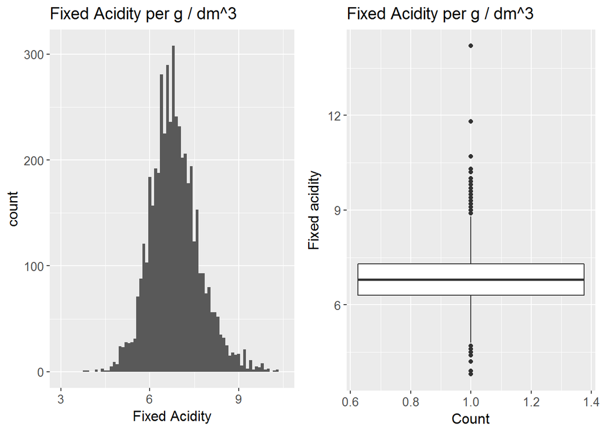

```
##    Min. 1st Qu.  Median    Mean 3rd Qu.    Max.
##  0.0800  0.2100  0.2600  0.2782  0.3200  1.1000
```

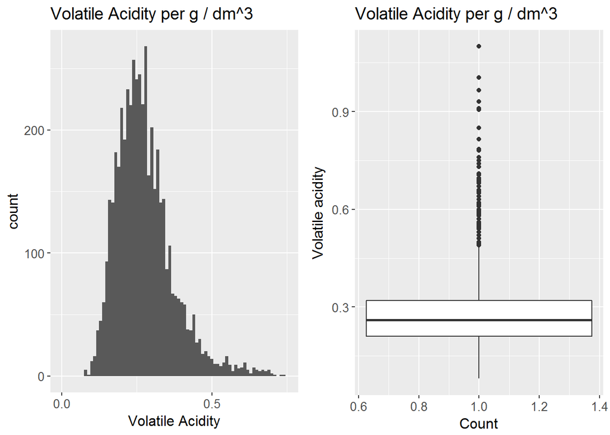

```
##    Min. 1st Qu.  Median    Mean 3rd Qu.    Max.
##  0.0000  0.2700  0.3200  0.3342  0.3900  1.6600
```

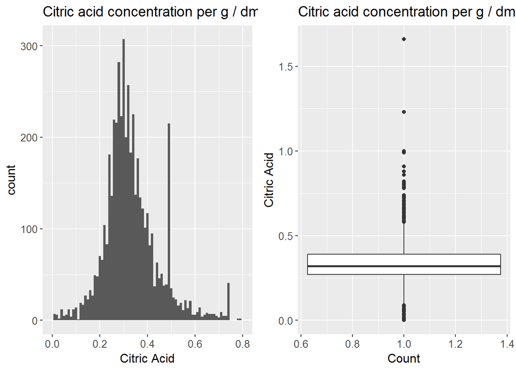

The plot has long tailed which after re - adjusting the axis could be normally distributed. Here the median of citric acid concentration is 0.32 g/dm^3 with an outlier at around 1.7.

```
##    Min. 1st Qu.  Median    Mean 3rd Qu.    Max.
##   0.600   1.700   5.200   6.391   9.900  65.800
```

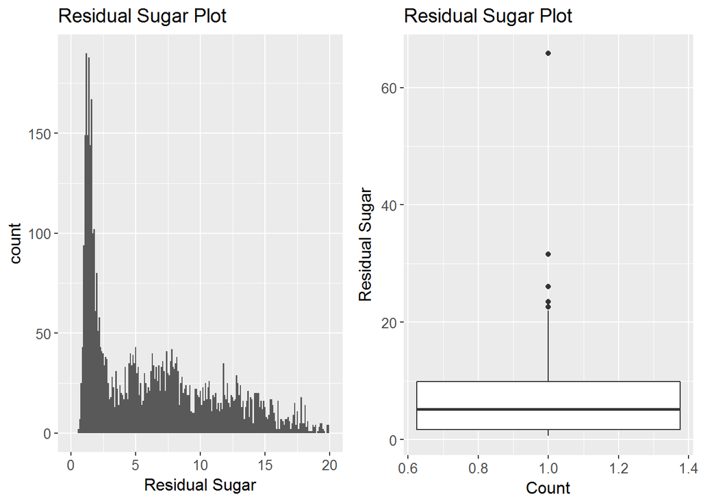

```
##    Min. 1st Qu.  Median    Mean 3rd Qu.    Max.
## 0.00900 0.03600 0.04300 0.04577 0.05000 0.34600
```

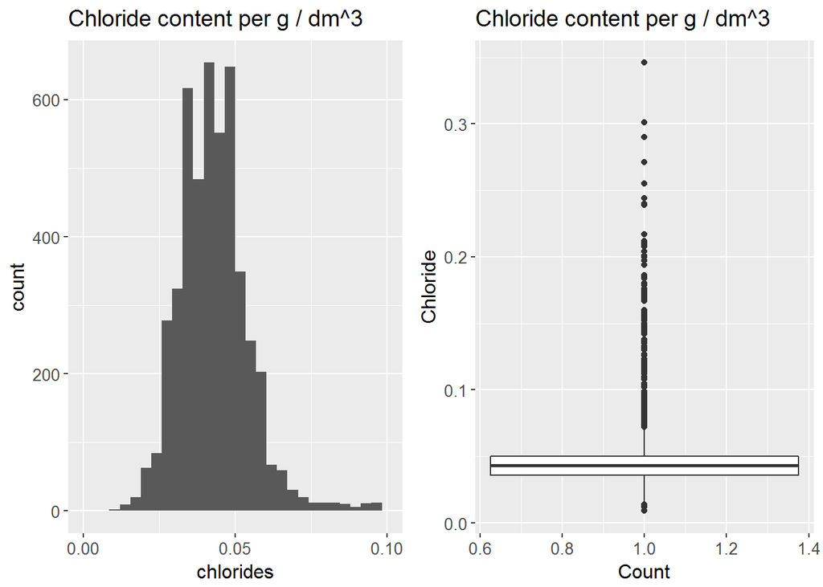

This visualization has a long tail with an outlier at around 0.34.This visualization appears slightly bimodal with rough peaks at around 0.03,0.05

```
##    Min. 1st Qu.  Median    Mean 3rd Qu.    Max.
##    2.00   23.00   34.00   35.31   46.00  289.00
```

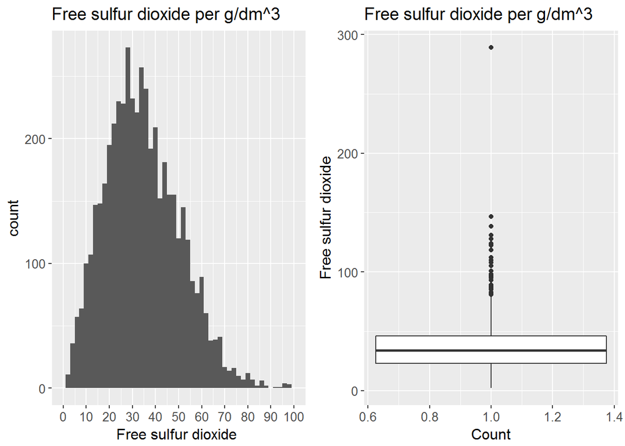

This graph has a median of free sulfur dioxide of 34 g/dm^3 and have an outlier at 289. On re-adjusting the axis to obtain an understanding of the shape of the plot.After readjusting the axis to remove the outlier and after limit the range of x-axis to 0-100 g/dm^3, the plot is clearly a normal distribution.

```
##    Min. 1st Qu.  Median    Mean 3rd Qu.    Max.
##     9.0   108.0   134.0   138.4   167.0   440.0
```

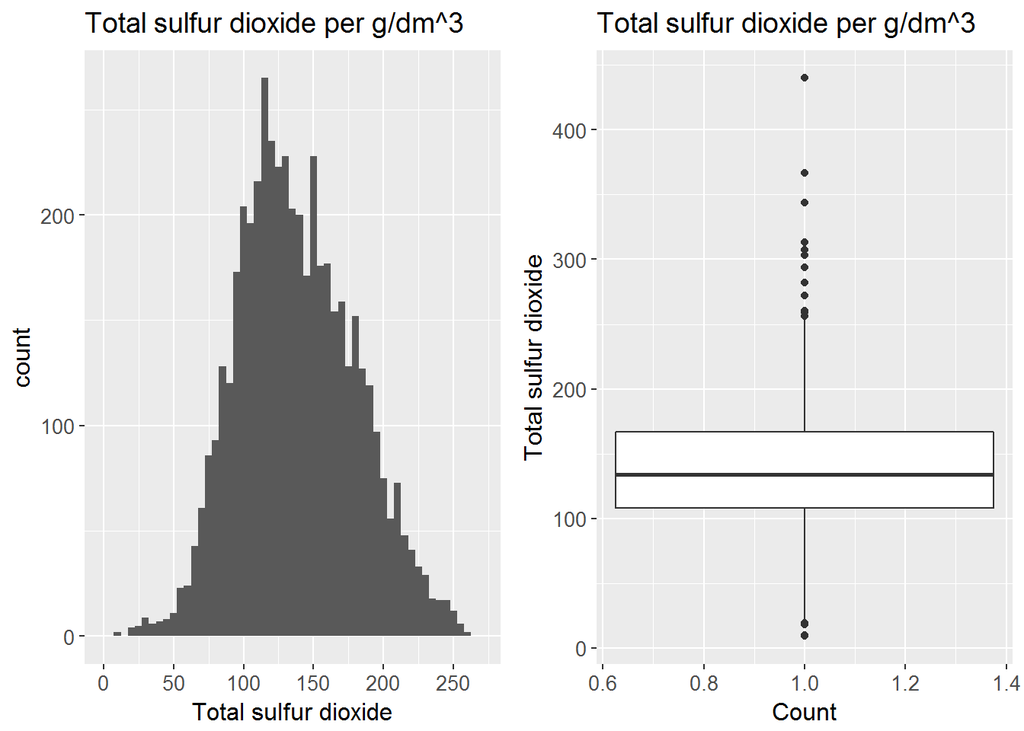

This plot is normally distributed with an outlier at 440 g/dm^3 with maximum concentration of sulfur dioxide at around 134 g/dm^3.

```
##    Min. 1st Qu.  Median    Mean 3rd Qu.    Max.
##  0.9871  0.9917  0.9937  0.9940  0.9961  1.0390
```

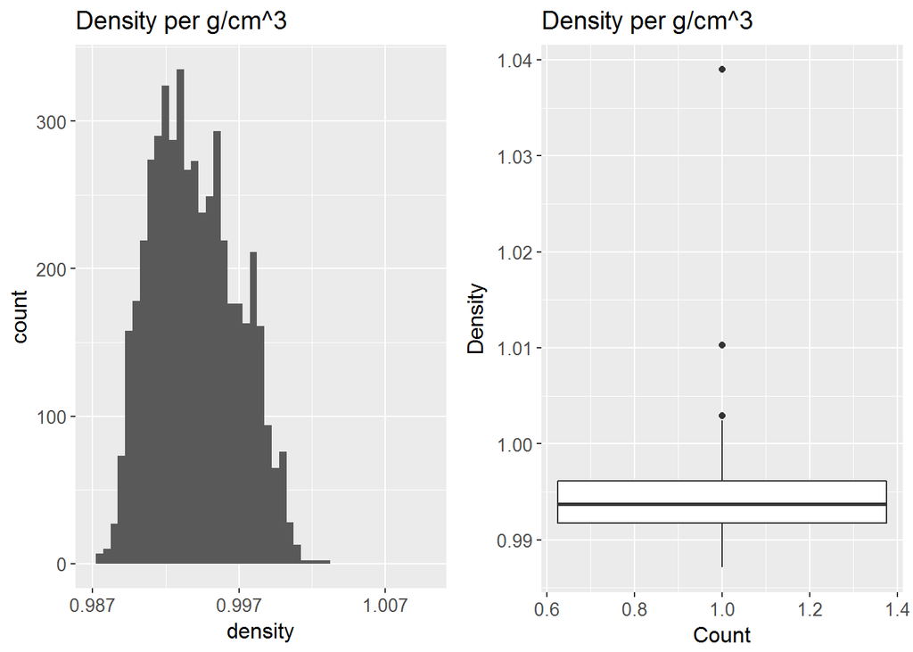

```
##    Min. 1st Qu.  Median    Mean 3rd Qu.    Max.
##   2.720   3.090   3.180   3.188   3.280   3.820
```

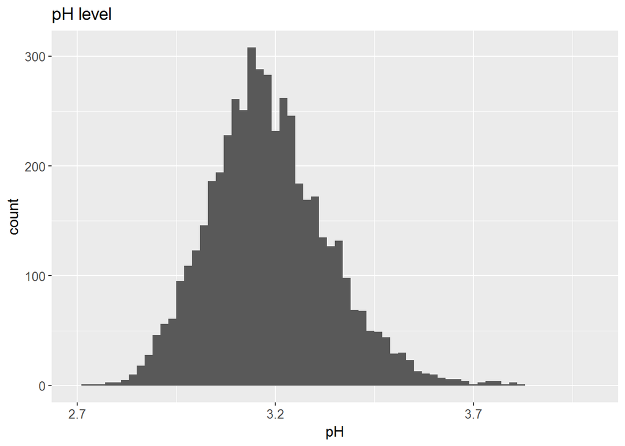

```
##    Min. 1st Qu.  Median    Mean 3rd Qu.    Max.
##  0.2200  0.4100  0.4700  0.4898  0.5500  1.0800
```

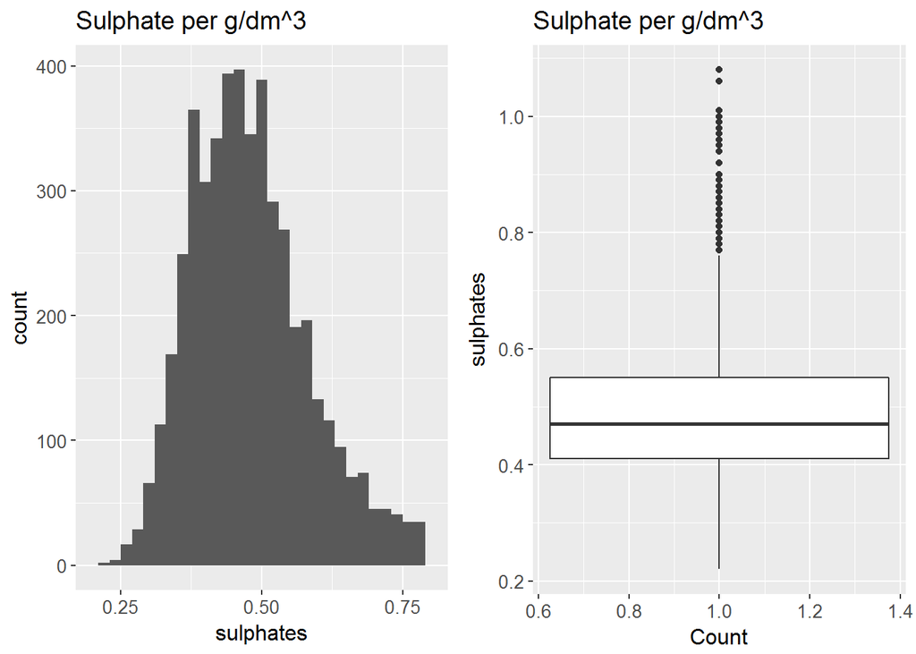

This plot is skewed to the right with a long tail and having an outlier at 1.08. The median of sulphate concentration is 0.47 g/dm^3.

```
##    Min. 1st Qu.  Median    Mean 3rd Qu.    Max.
##    8.00    9.50   10.40   10.51   11.40   14.20
```

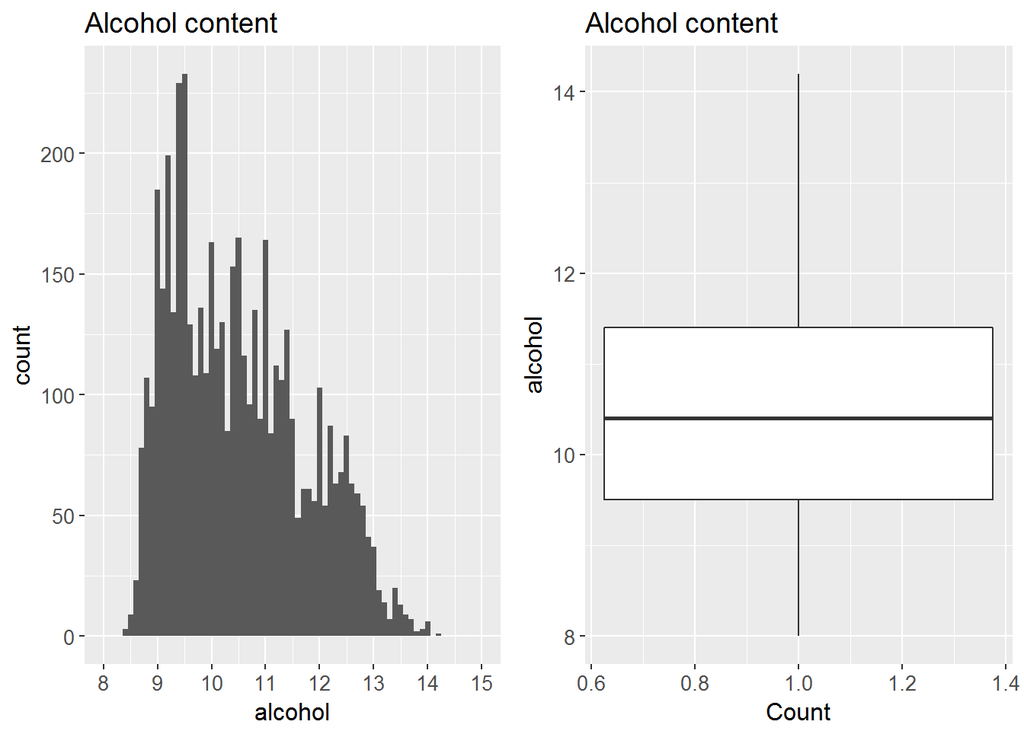

```
##    Min. 1st Qu.  Median    Mean 3rd Qu.    Max.
##   3.000   5.000   6.000   5.878   6.000   9.000
```

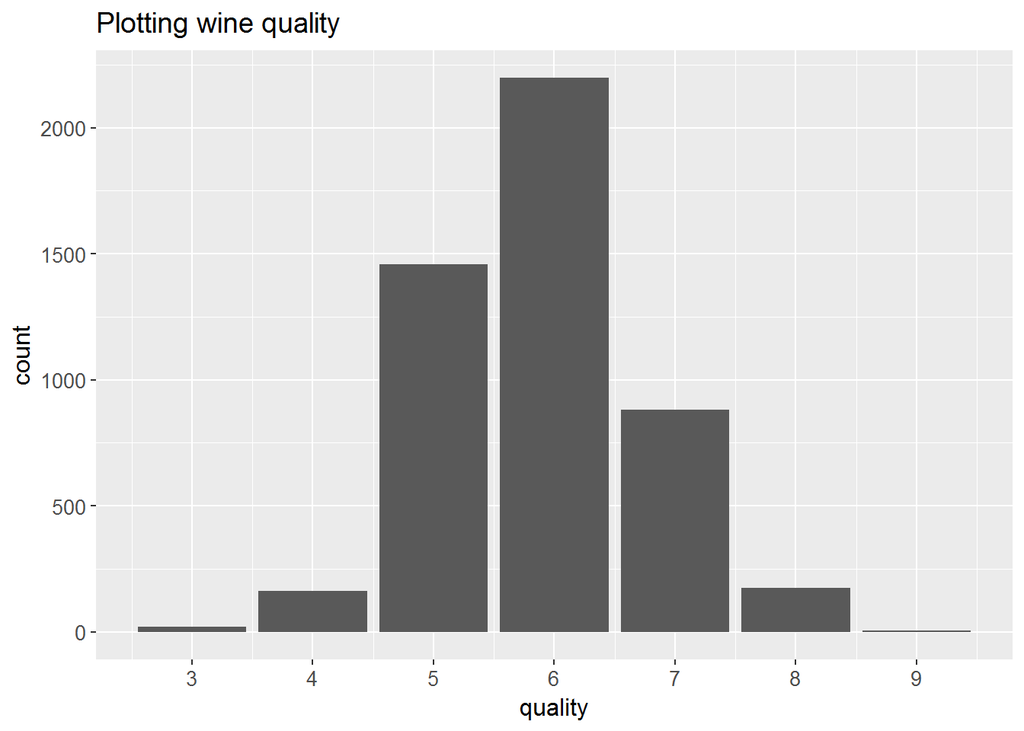

# Univariate Analysis

### What is the structure of your dataset?

There are 4898 observations of white wine in this dataset with 13 variables. The first variable ‘X’ is a unique identifier for each record so it is ignored in my analysis. Other variables like fixed.acidity, volatile.acidity, citric.acid,residual.sugar,chlorides,free.sulfur.dioxide,total.sulfur.dioxide, density,pH,sulphates,alcohol are all numeric variables with quality being an integer variable.

### What is/are the main feature(s) of interest in your dataset?

My main point of interest is determing the factors which determine the quality of white wine.

### What other features in the dataset do you think will help support your investigation into your feature(s) of interest?

I would need to compute the correlation of each of the variables like fixed.acidity, volatile.acidity,citric.acid,residual.sugar,chlorides, free.sulfur.dioxide,total.sulfur.dioxide, density,pH,sulphates,alcohol with the quality to determine which variables influence the quality and hence the taste of white wine. I will explore these relationships in the later sections of my report.

### Did you create any new variables from existing variables in the dataset?

I have added the following variable in the dataset :  
* **rating** : which is calculated on the basis of the quality of the white wine. With 3-5 for “Bad”, 6-7 for “Average” and 8-9 as “Good” rating. This factored variable will help me in later investigating the relationship of variables with the wine quality  
* **total.acidity** : Calculated as sum of fixed and volatile acidity  
* **wine.type** : Classifies wine on the basis of sugar content, with wines less than 10 sugar as “Dry”, more than 30 as “sweet” and the others as “Medium” * **citric_acid_bucket** : Groups citric acid into buckets of [0-0.3],(0.3-0.6], (0.6,1.7]  
* **total_sulfur_dioxide_bucket** : Groups total sulfur dioxide into buckets of [0-120],(120-210],(210,440]  
* **alchol_content** : Classifies wine on the basis of alcohol content, with wines content less than 12.5 as “Low”, between 12.5 to 13.5 as “Moderately Low” and the others as “High”  
* **chloride_sulfate_ratio** : Classifies the proportion of chloride with sulfates with proportion less than 0.5 as “Very Bitter” and others as “Bitter”

# Bivariate Plots Section

Here in this section I would like to explore the relationship among couple of variable pairs which have a strong/weak relationship among them.

Analysis of relationship between the variables

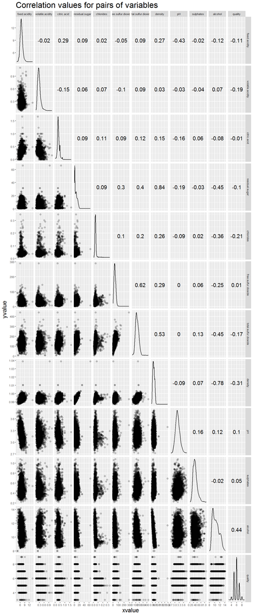

Numeric correlations among the variables

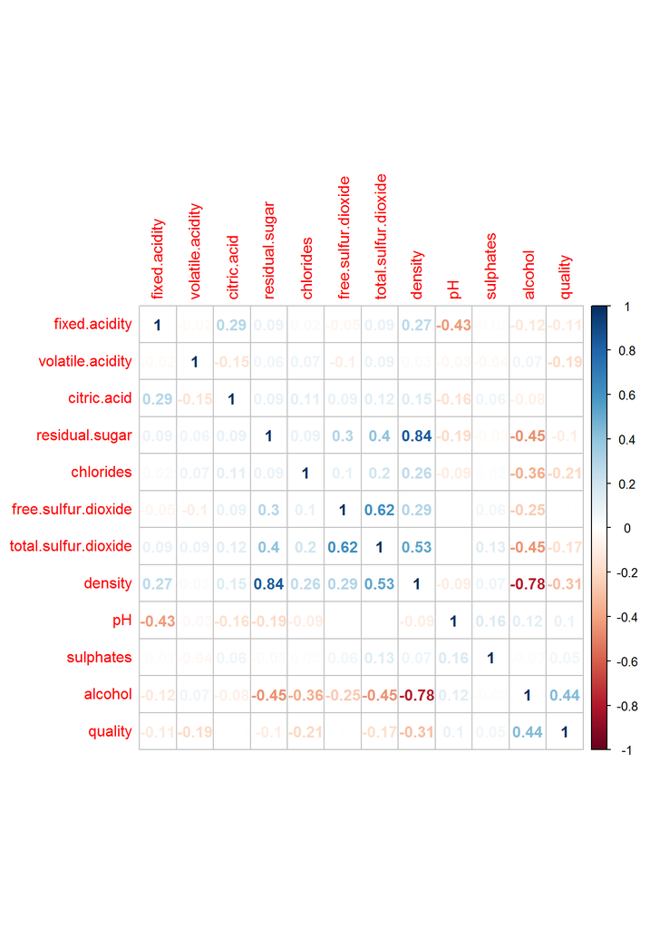

From the above plot the top most positive and negative correlation coefficients, r based on strength of association[1] are

- Residual sugar: density = 0.8389665
- Free sulfur dioxide: Total sulfur dioxide=0.615501
- Alcohol: quality = 0.4355747
- Total sulfur dioxide: density = 0.5298813
- Fixed acidity:Citric acid=0.2891807
- Chlorides:Density=0.2572113
- Density:quality= -0.3071233
- Alcohol:Residual sugar=-0.4506312
- Alcohol:Density= -0.7801376
- Fixed.acidity:pH= -0.4258583
- Alchohol: Total sulfur dioxide = -0.4488921
- Alcohol: Chloride = -0.3601887

I will exploring some of these relationships in this section of the report.

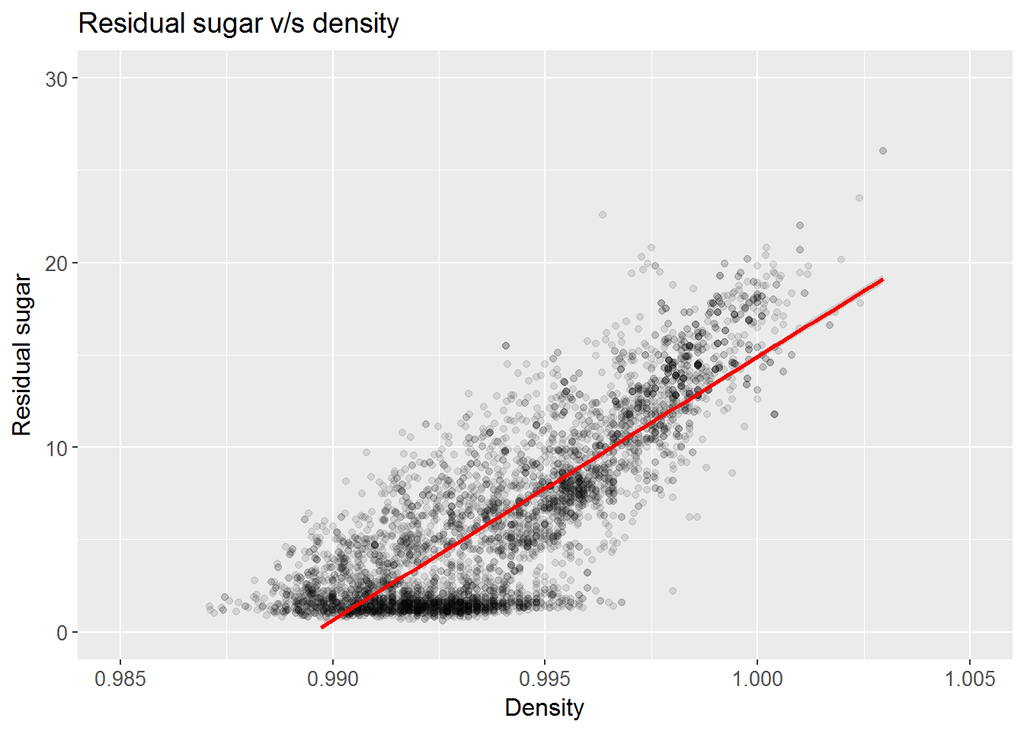

This plot shows that as residual sugar in white wine increases, the density increases.

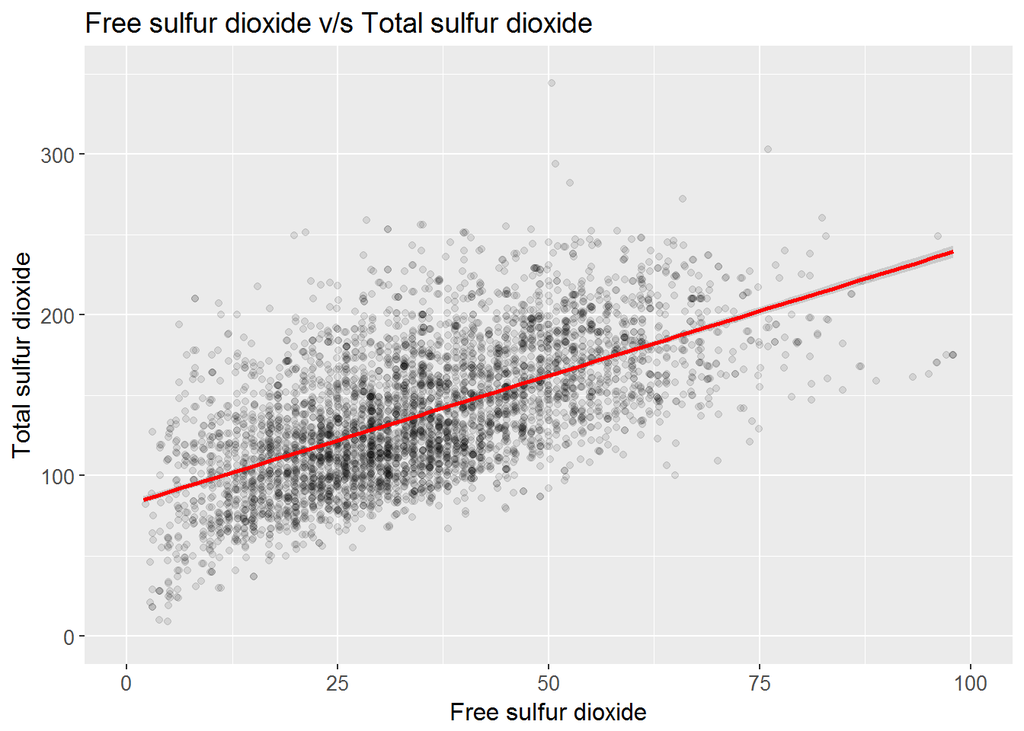

This plot shows that with increase in free sulfur dioxide the proportion of total sulfur dioxide increases.

```
## white_wine_df$rating: Average
##    Min. 1st Qu.  Median    Mean 3rd Qu.    Max.
##     8.5     9.8    10.8    10.8    11.8    14.2
## --------------------------------------------------------
## white_wine_df$rating: Bad
##    Min. 1st Qu.  Median    Mean 3rd Qu.    Max.
##    8.00    9.20    9.60    9.85   10.40   13.60
## --------------------------------------------------------
## white_wine_df$rating: Good
##    Min. 1st Qu.  Median    Mean 3rd Qu.    Max.
##    8.50   11.00   12.00   11.65   12.60   14.00
```

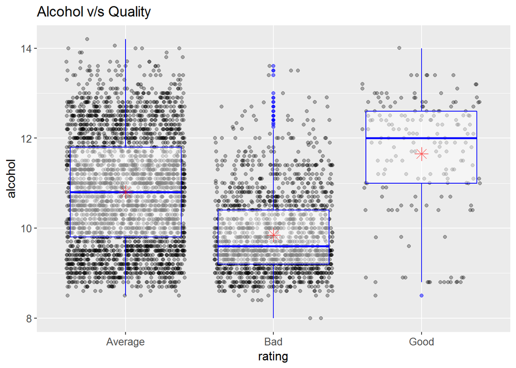

This plot shows that good quality of wine had high median of 12.0 alcohol. This visualisation shows that as alcohol content increase the quality of wine increases.

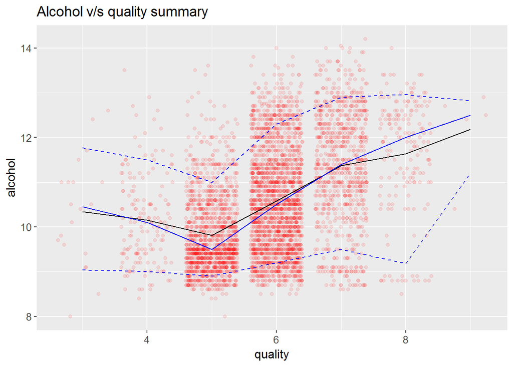

This plot the summary statistic between alcohol and quality with black line representing the mean, and the 0.9,0.5,0.1 quantile relationship between the two.

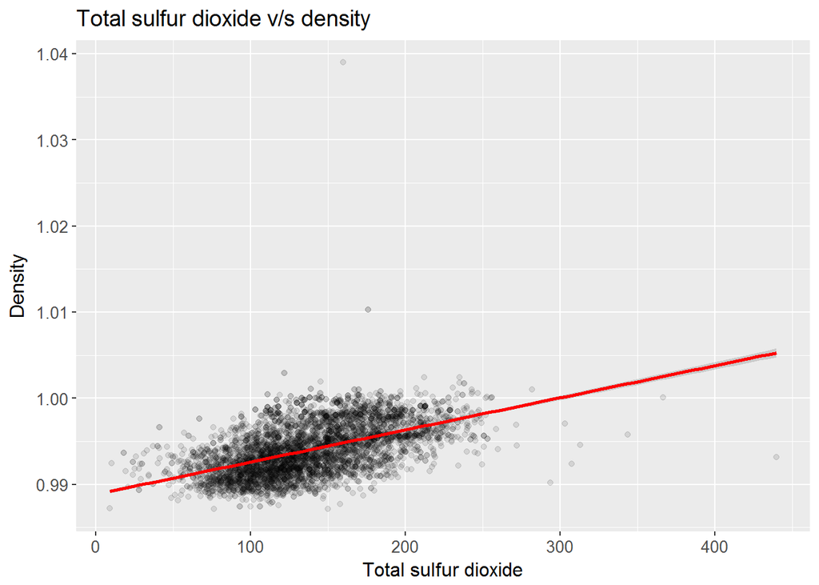

This plot shows that with increase in total sulfur dioxide the density of white wine increases.

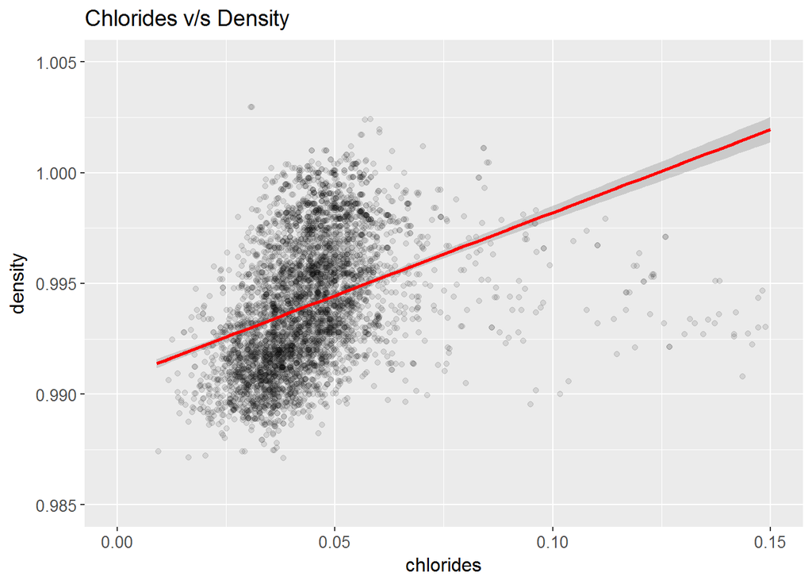

This plot shows that with increase in chlorides the density of white alcohol as well increases.

```
## white_wine_df$rating: Average
##    Min. 1st Qu.  Median    Mean 3rd Qu.    Max.
## 0.01200 0.03400 0.04100 0.04321 0.04800 0.25500
## --------------------------------------------------------
## white_wine_df$rating: Bad
##    Min. 1st Qu.  Median    Mean 3rd Qu.    Max.
## 0.00900 0.04000 0.04700 0.05144 0.05300 0.34600
## --------------------------------------------------------
## white_wine_df$rating: Good
##    Min. 1st Qu.  Median    Mean 3rd Qu.    Max.
## 0.01400 0.03000 0.03550 0.03801 0.04400 0.12100
```

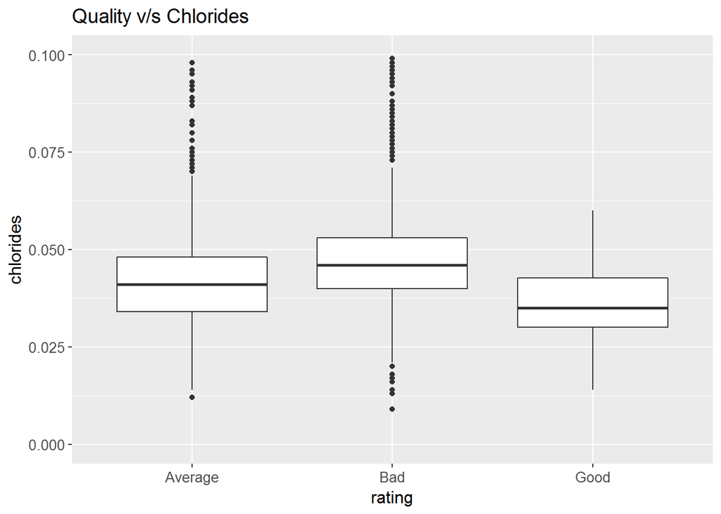

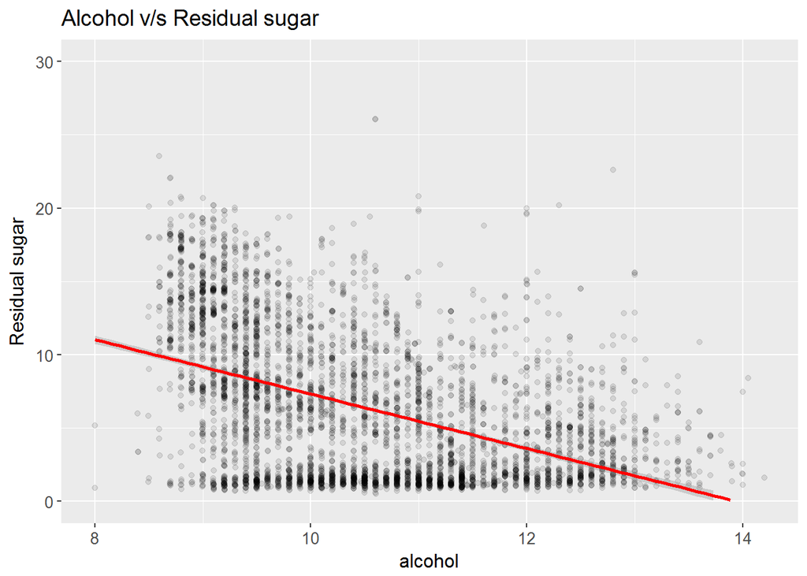

This plot shows that large number of wines have residual sugar content decrease as alcohol proportion increases.

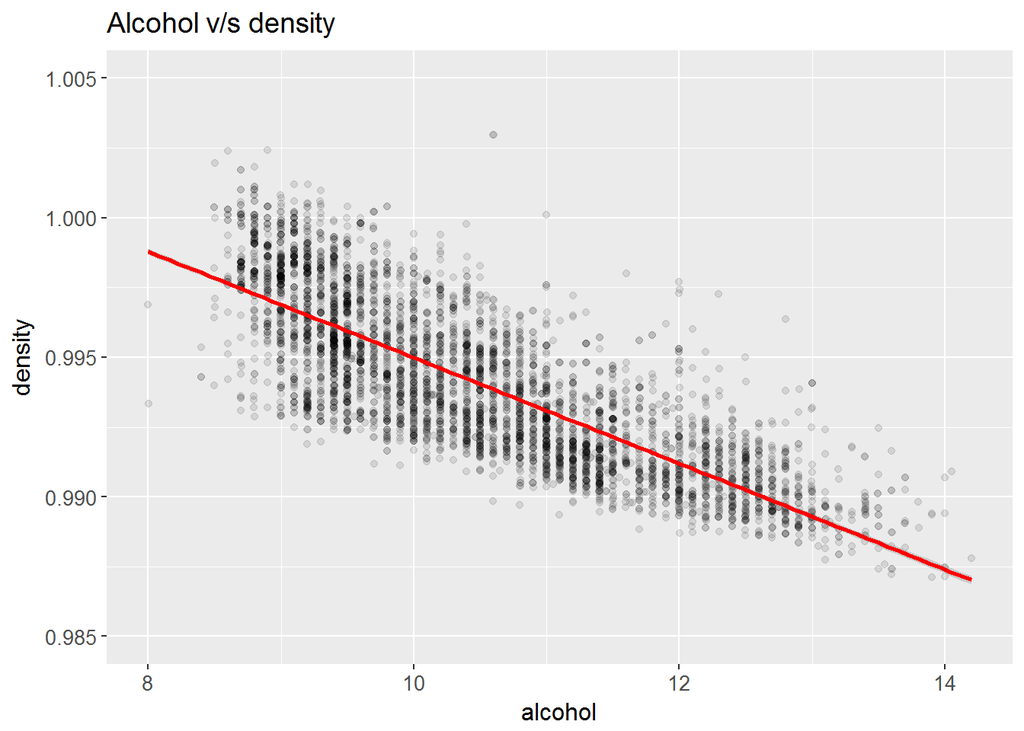

This plot shows that large number of wines have density reduced as the alcohol proportion increases

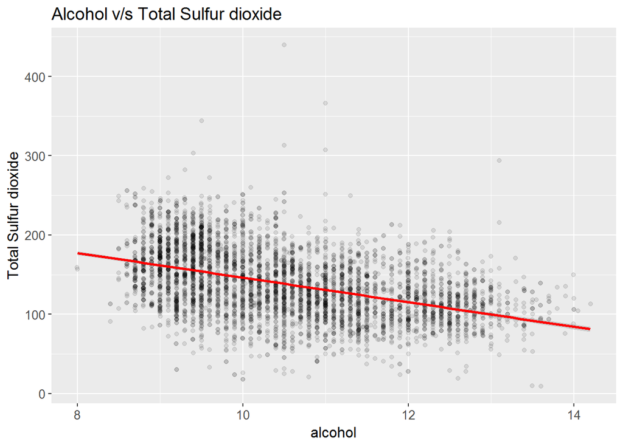

These plot show that as alcohol in white wine increase the total sulfur dioxide content decreases.

# Bivariate Analysis

### Talk about some of the relationships you observed in this part of the investigation. How did the feature(s) of interest vary with other features in the dataset?

Here in this investigation I observed strong relation between alcohol and quality,residual sugar and density,free and total sulfur dioxide,fixed acidity and citric acid, chlorides and density.

The correlation constant values of other variables in the dataset wrt to quality are :

- citric.acid:quality = -0.009209091
- free.sulfur.dioxide:quality = 0.008158067
- fixed.acidity: quality= -0.1136628
- volatile.acidity:quality = -0.194723
- residual.sugar:quality = -0.09757683
- chlorides:quality = -0.2099344
- total.sulfur.dioxide:quality = -0.1747372
- density:quality = -0.3071233
- pH:quality = 0.09942725
- sulphates:quality=0.05367788
- alcohol: quality=0.4355747

### Did you observe any interesting relationships between the other features (not the main feature(s) of interest)?

I observed positive correlation between free and total sulfur dioxide(0.615501), alcohol and quality(0.4355747),Fixed acidity and Citric acid(0.2891807), Chlorides and Density(0.2572113) and negative correlation between density and quality(-0.3071233), Alcohol and Residual sugar(-0.4506312), Alcohol and Density(-0.7801376) and Fixed acidity and pH(-0.4258583)

### What was the strongest relationship you found?

I found the strongest positive correlation between residual sugar and density with correlation constant value of 0.8389665.

# Multivariate Plots Section

Here in this section I will like to explore the relationship of 2 or more variables with respect to wine rating

In wine tasting, humans are least sensitive to the taste of sweetness (in contrast to sensitivity to bitterness or sourness) with the majority of the population being able to detect sugar or “sweetness” in wines between 1% and 2.5% residual sugar. Additionally, other components of wine such as acidity and tannins can mask the perception of sugar in the wine.

First I will like to explore the relationship of residual sugar with density and does it impact the wine rating

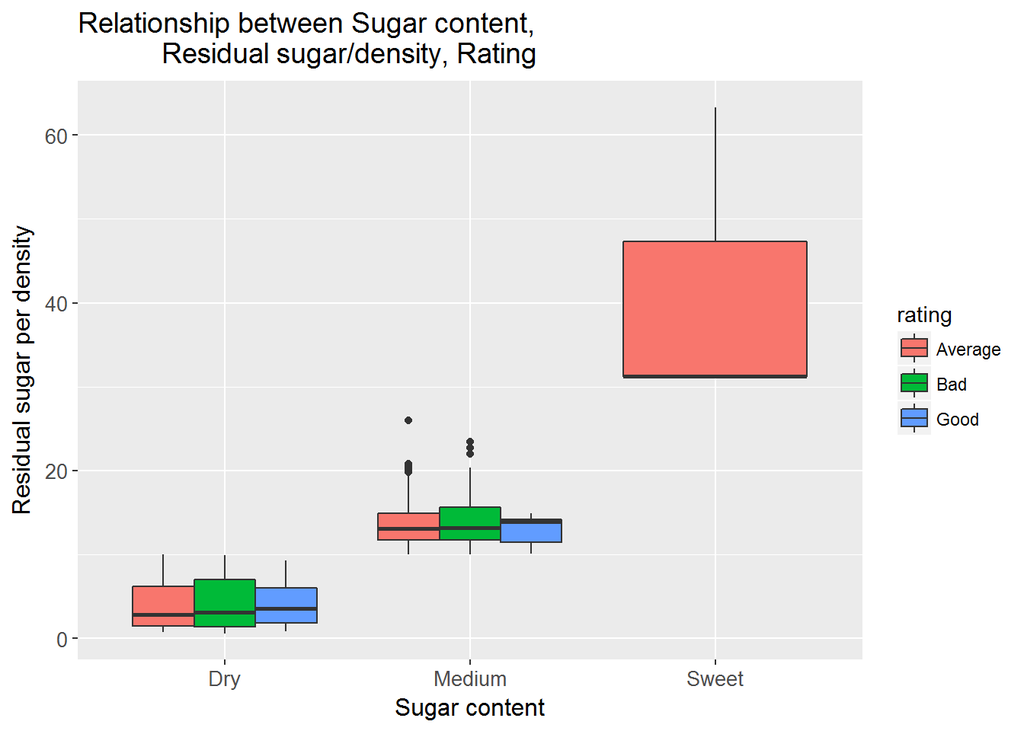

This plot explores the relationship between wine sweetness to residual sugar per density and how it impacts the wine rating. It shows that as sweetness level of wines increase, the density as well increases. And it shows that sweet wines have higher sugar/density and are just averagely rated.

Lets go upon exploring the relationship between free and total sulfur dioxide with respect to the wine rating

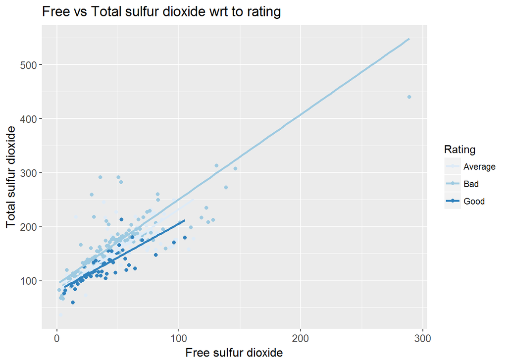

Acids are one of 4 fundamental traits in wine (the others are tannin, alcohol and sweetness). Acidity gives wine its tart and sour taste. SO let us go on by exploring the total acidity(fixed+volatile) with respect to wine rating.

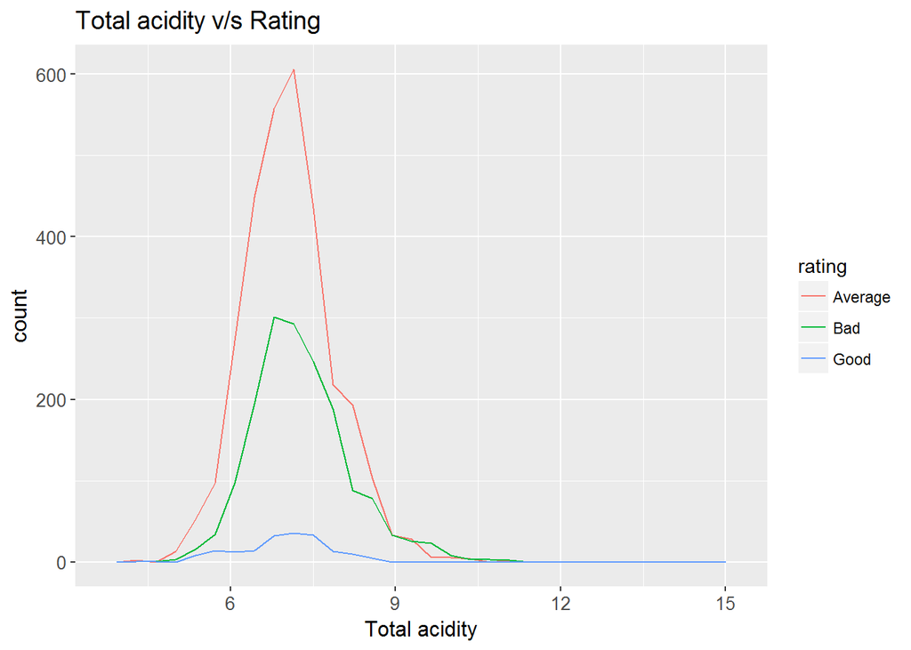

This plot shows the density curve for differently rated wines - Good, Bad and average with respect to their total acidity. Here the density of total acidity of average rated wines is the maximum, followed by bad wines and then by good wines.

**Citric acid** is a weak organic acid, which is often used as a natural preservative or additive to food or drink to add a sour taste to food.In terms of wines it is often added to wines to increase acidity,or to give a “fresh” flavor. Let us explore the relationship of citric acid with total and volatile acidity and corresponding sugar level in the wines

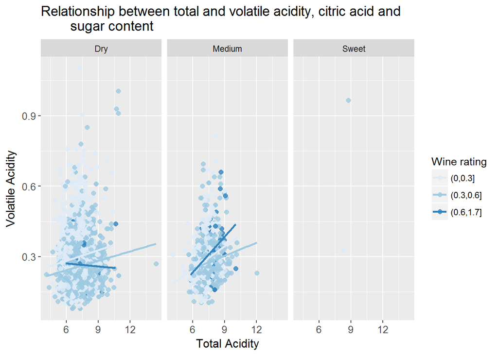

This multi variate scatter plot groups wines based on sugar content and citric acid content. For dry wines, most of citric acid content falls within bucket of (0,0.3] with low level of total acidity and medium volatile acidity. Dry wines also contain prominent wines with citric acid in bucket of (0.3,0.6] which are scattered for volatile acidity and fixed acidity. Medium wines have higher proportion of wines in (0.6,1.7] citric acid bucket as compared to dry wines. And for wines with content between 0-0.6 citric acid content is medium with total and volatile acidity proportion.

Let us explore the relationship of citric acid with alcohol and total acidity and sweetness.

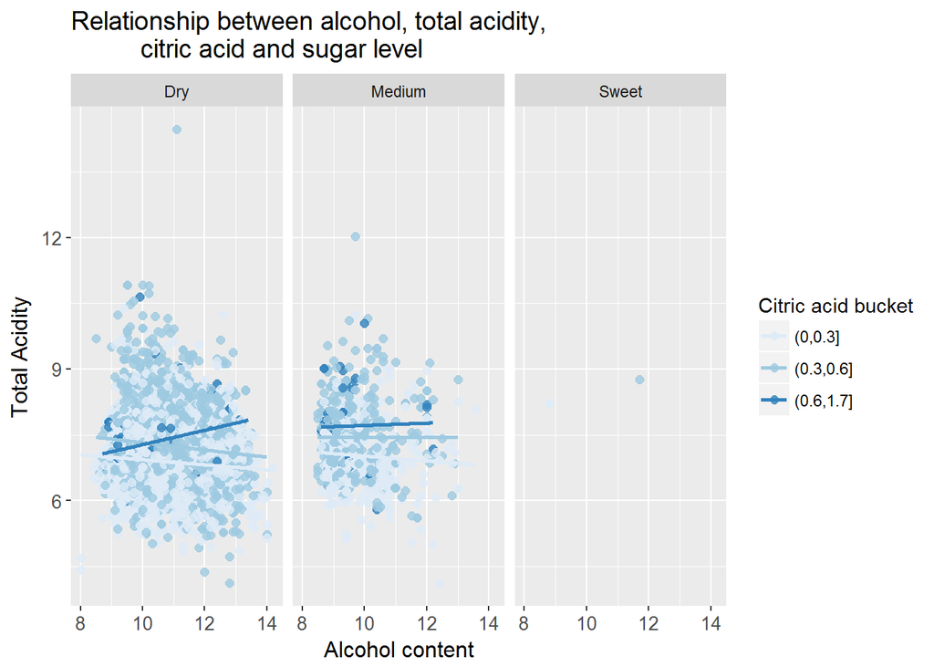

Chloride concentrations in excess tend to give a full malty taste while Sulfate ions, in contrast, tend to accentuate hop flavors and bitterness. So let us analyze this relationship wrt to alcohol, the total acidity and sugar level to determine the balance in flavours

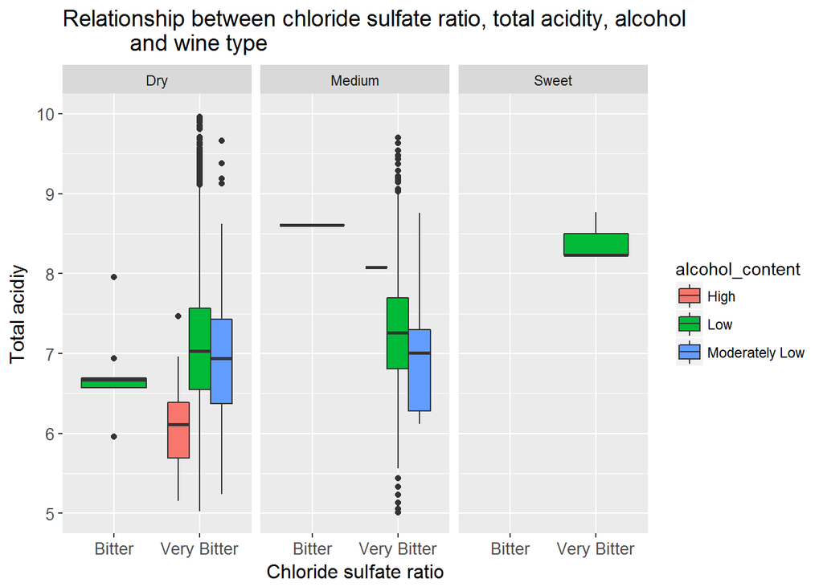

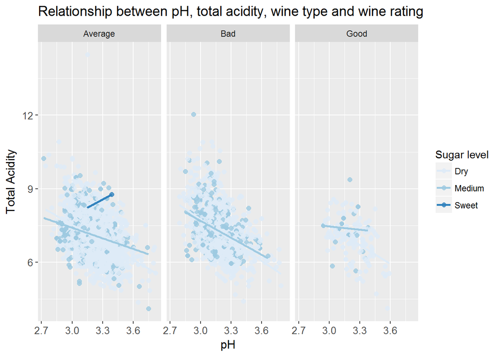

This plot explores the relationship of pH wrt to fixed acidity on basis of sweetness and wine rating. This shows that good wines haves low level of total acidity and are normally dry/medium level of sweetness.And bad wines more dry/medium level of sweetness as compared to good wines.